# Clustering and validation

Carlos Quesada

22/04/2021

# Dataset: Goiener (only households)

## Set of features: seasonal aggregates

### Clustering: Hierarchical

#### Internal measures: Connectivity (min)

File: meas_11111_1.png

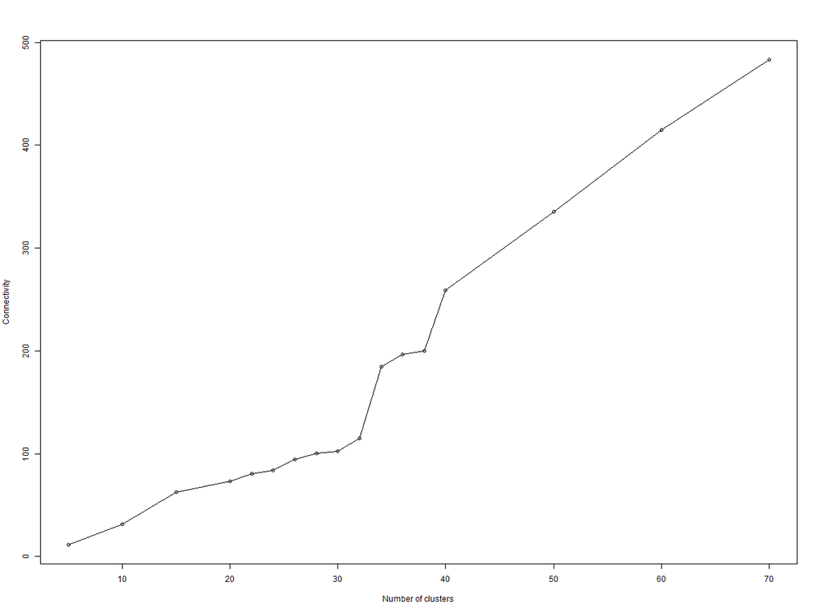

#### Internal measures: Dunn index (max)

File: meas_11111_2.png

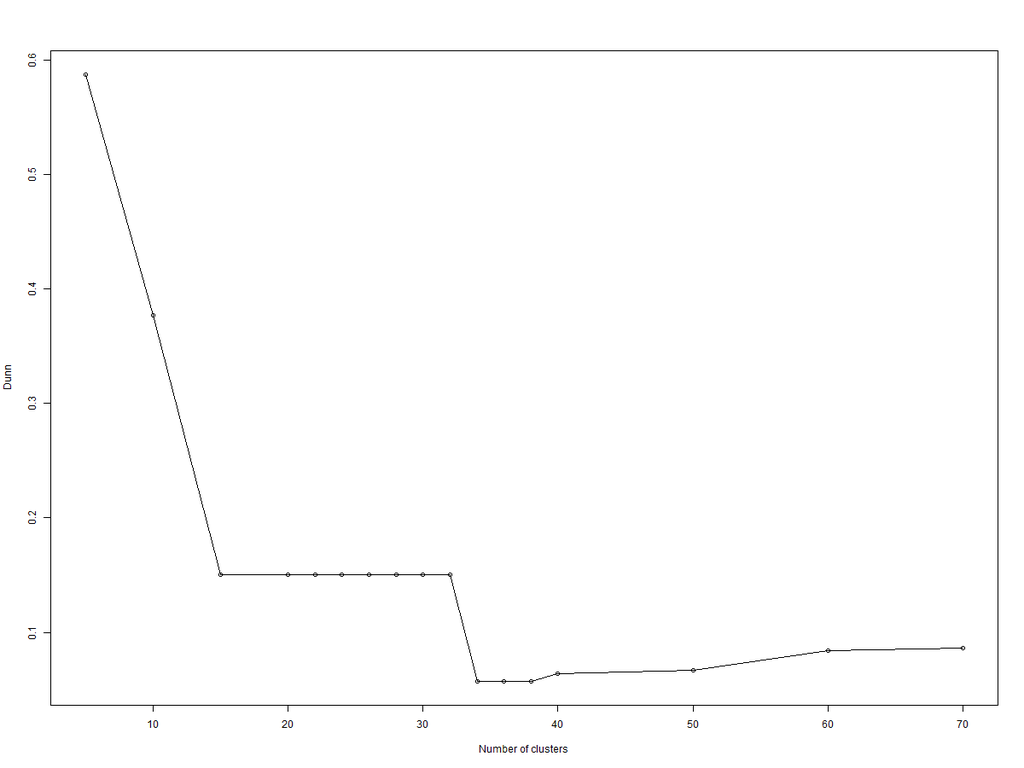

#### Internal measures: Silhouette (max)

File: meas_11111_3.png

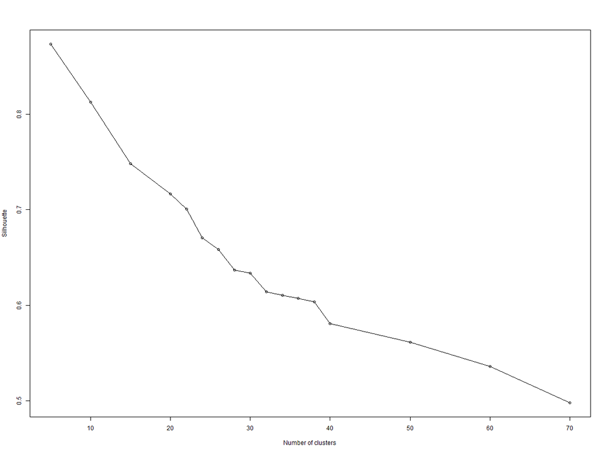

#### Stability measures: APN (min)

File: meas_11121_1.png

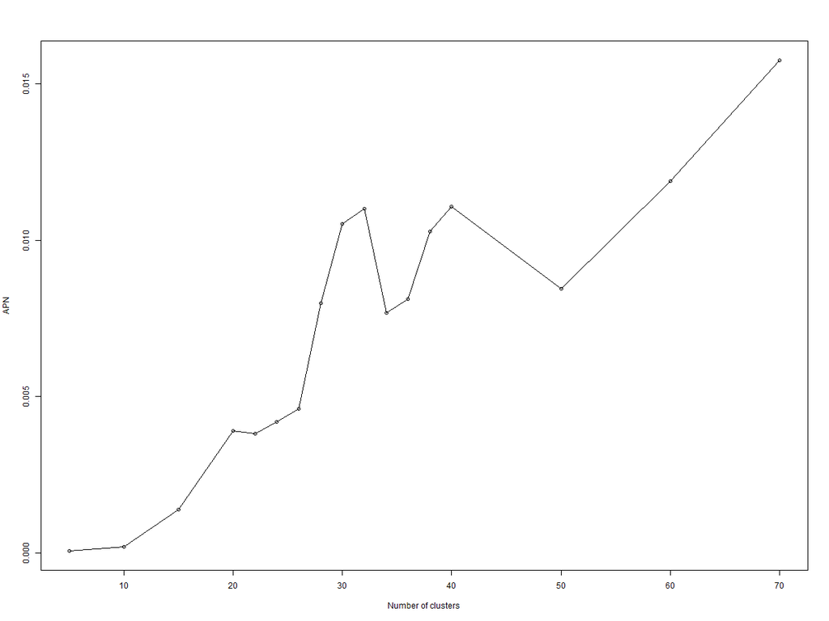

#### Stability measures: AD (min)

File: meas_11121_2.png

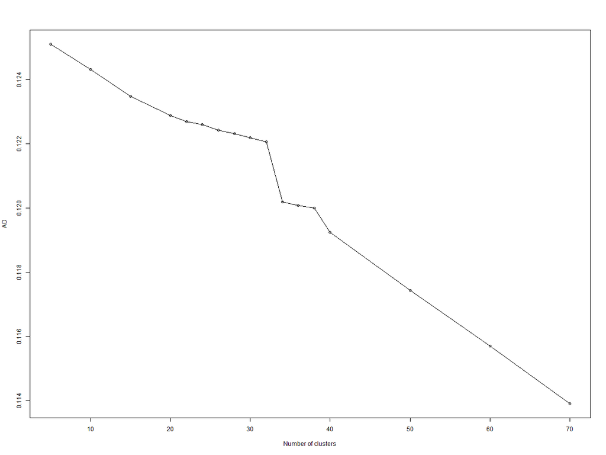

#### Stability measures: ADM (min)

File: meas_11121_3.png

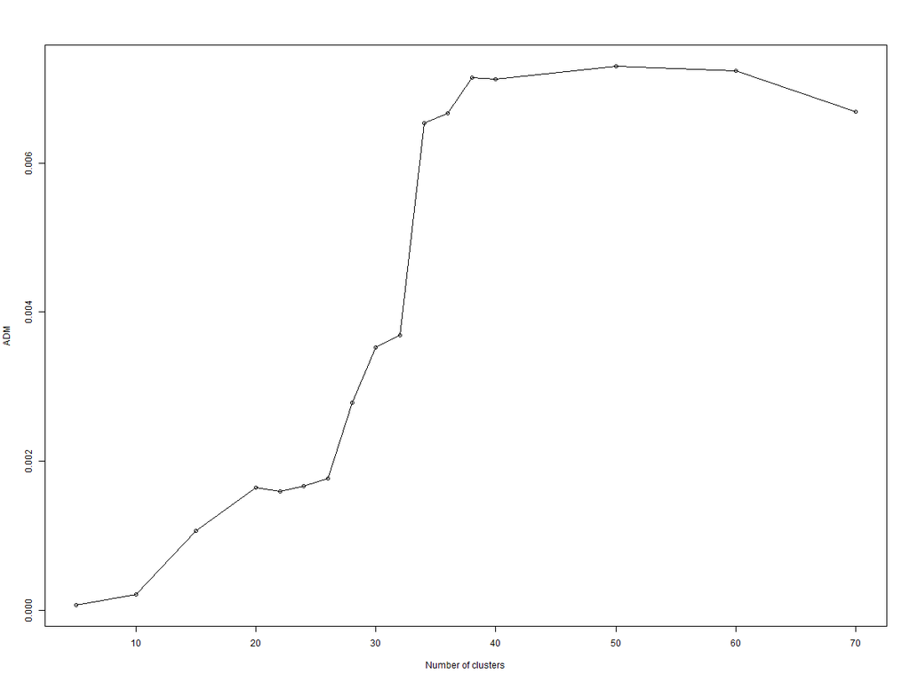

#### Stability measures: FOM (min)

File: meas_11121_4.png

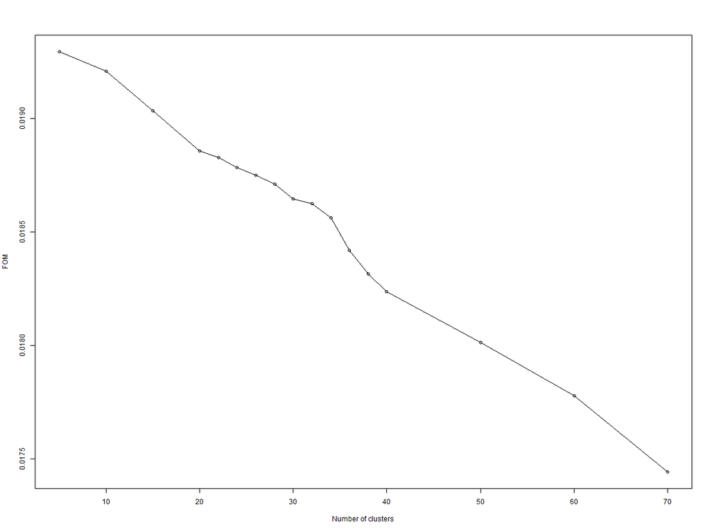

### Clustering: k-means

#### Internal measures: Connectivity (min)

File: meas_11211_1.png

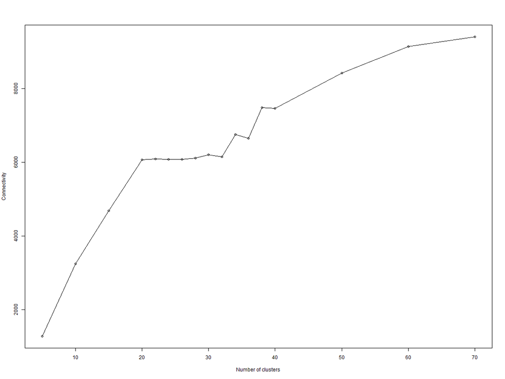

#### Internal measures: Dunn index (max)

File: meas_11211_2.png

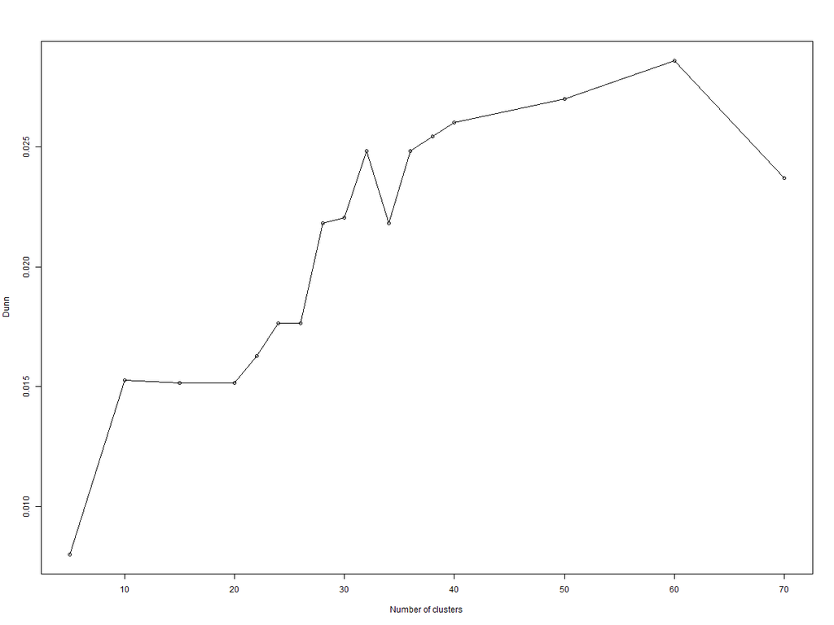

#### Internal measures: Silhouette (max)

File: meas_11211_3.png

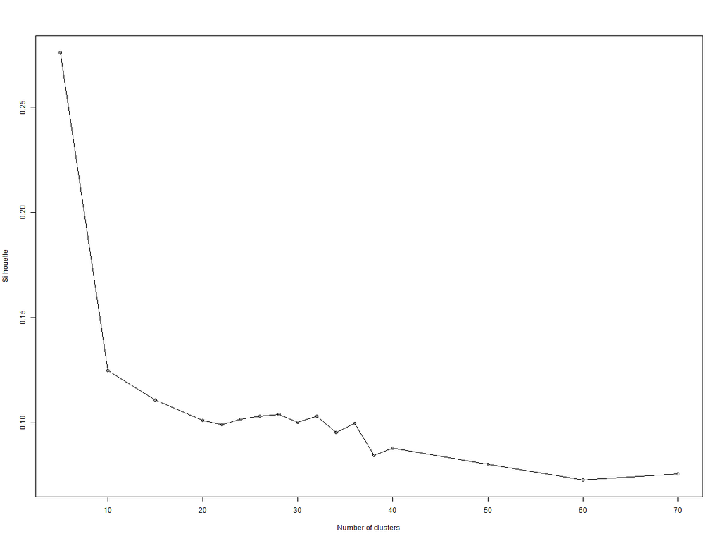

#### Stability measures: APN (min)

File: meas_11221_1.png

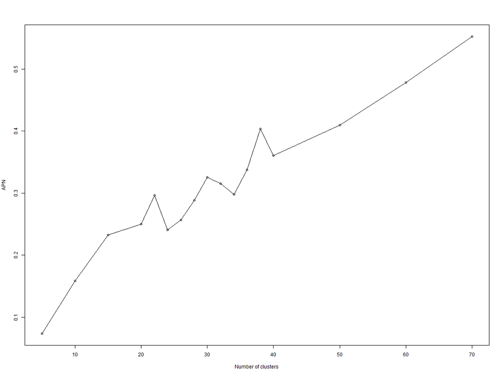

#### Stability measures: AD (min)

File: meas_11221_2.png

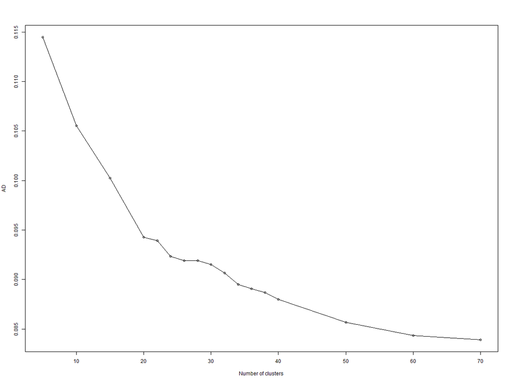

#### Stability measures: ADM (min)

File: meas_11221_3.png

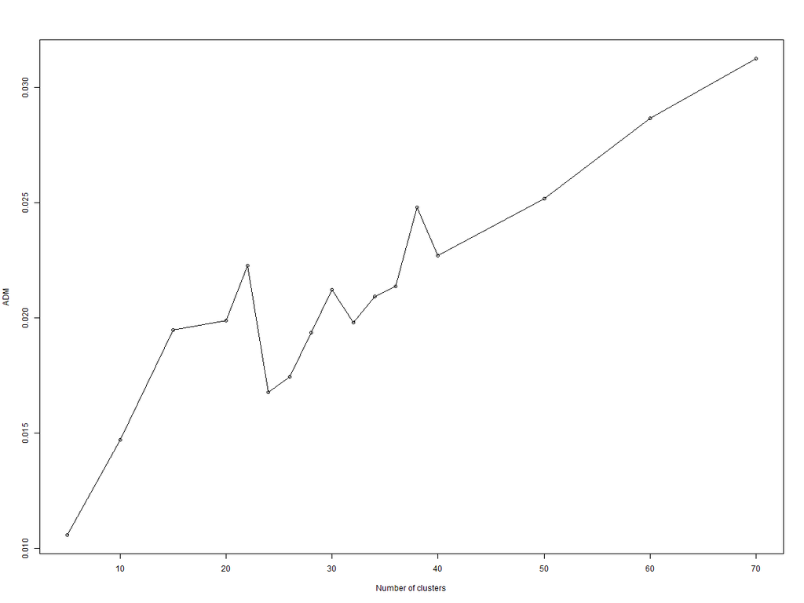

#### Stability measures: FOM (min)

File: meas_11221_4.png

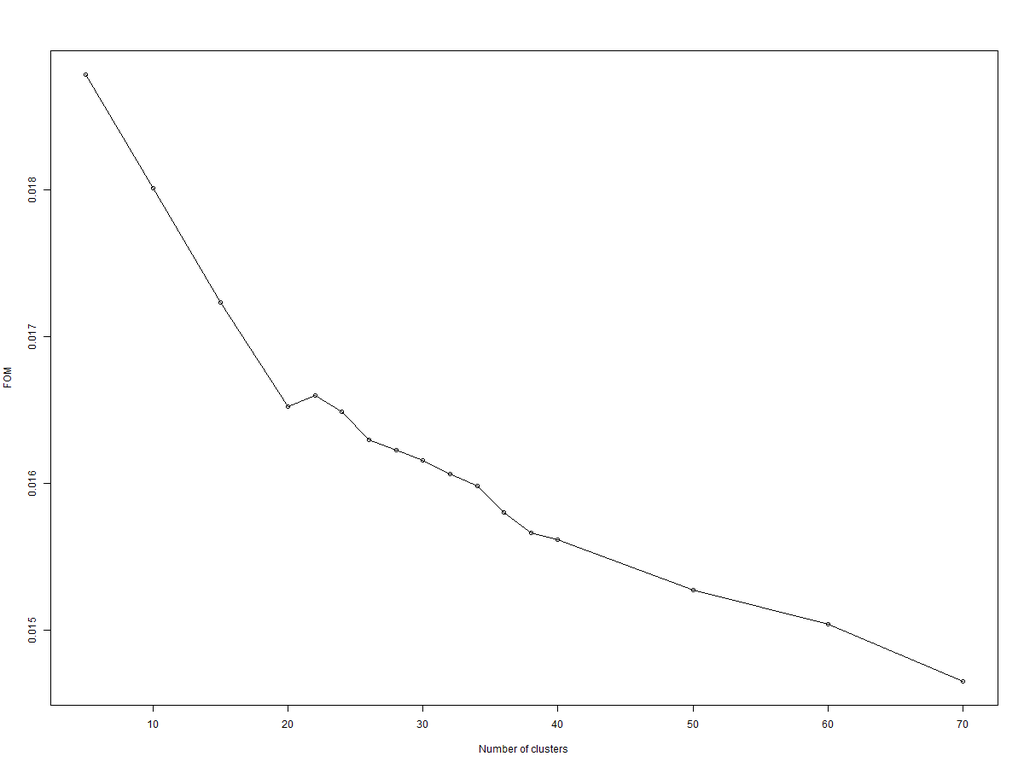

### Clustering: DIANA

#### Internal measures: Connectivity (min)

File: meas_11311_1.png

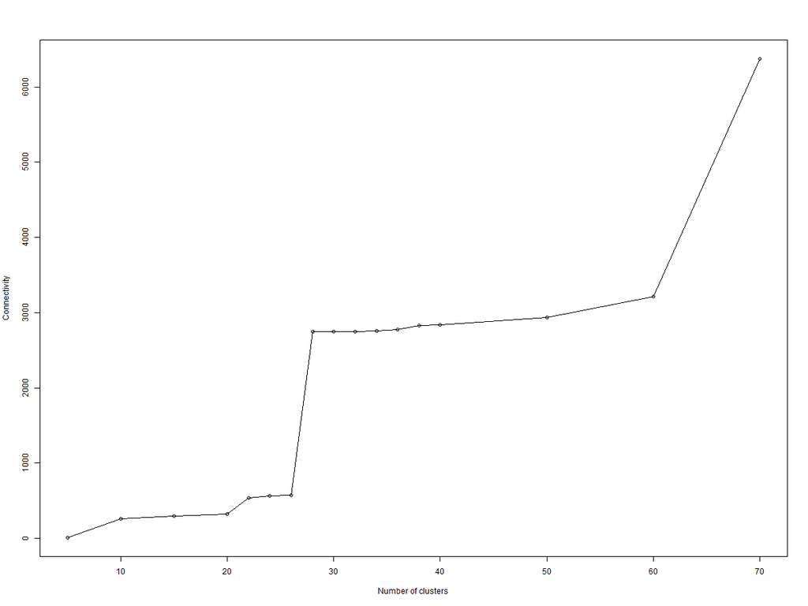

#### Internal measures: Dunn index (max)

File: meas_11311_2.png

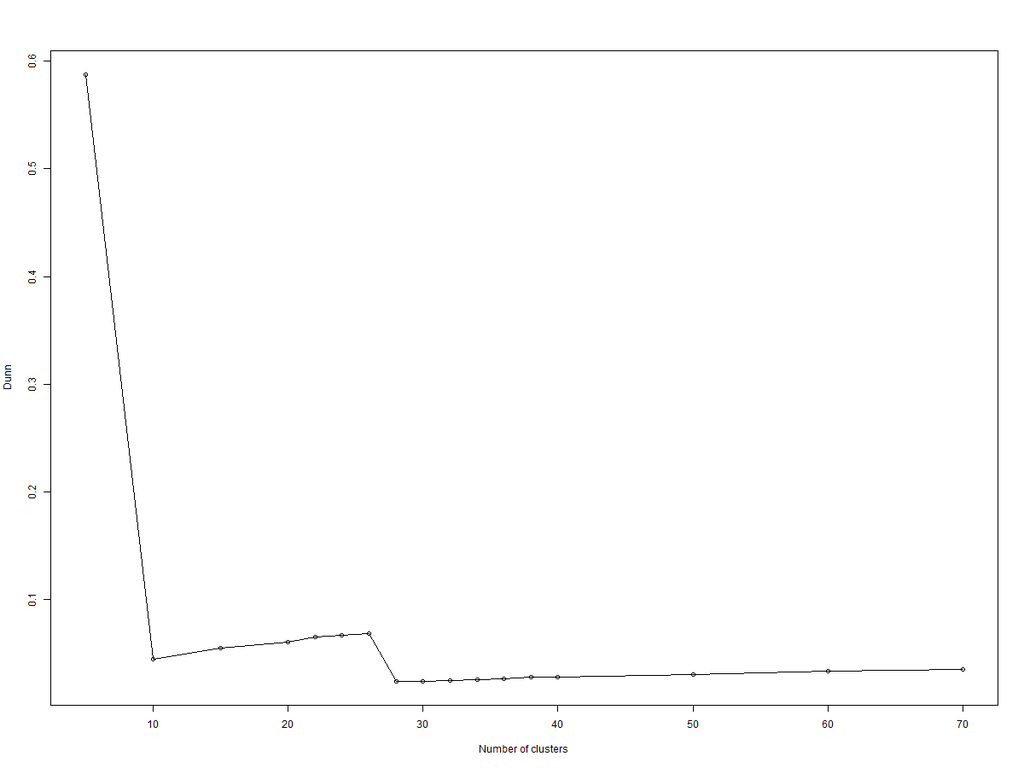

#### Internal measures: Silhouette (max)

File: meas_11311_3.png

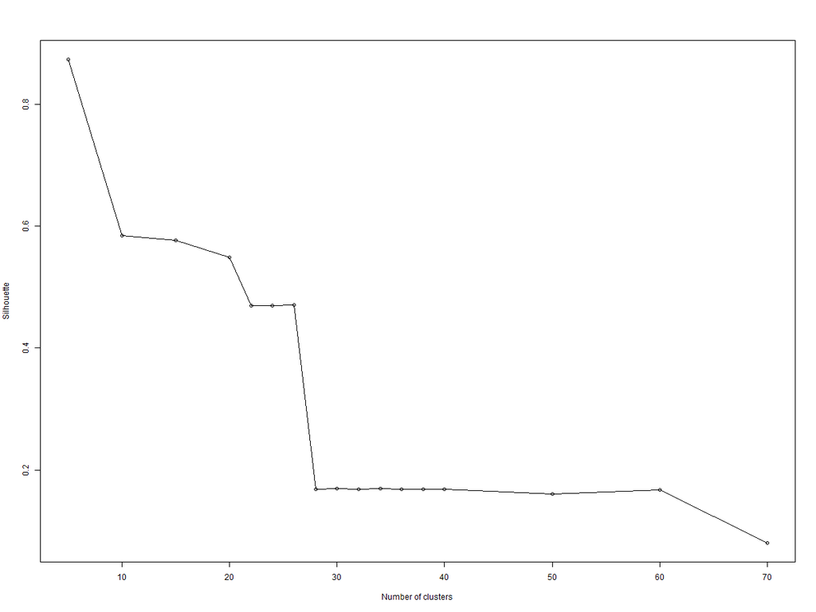

### Clustering: SOM

#### Internal measures: Connectivity (min)

File: meas_11511_1.png

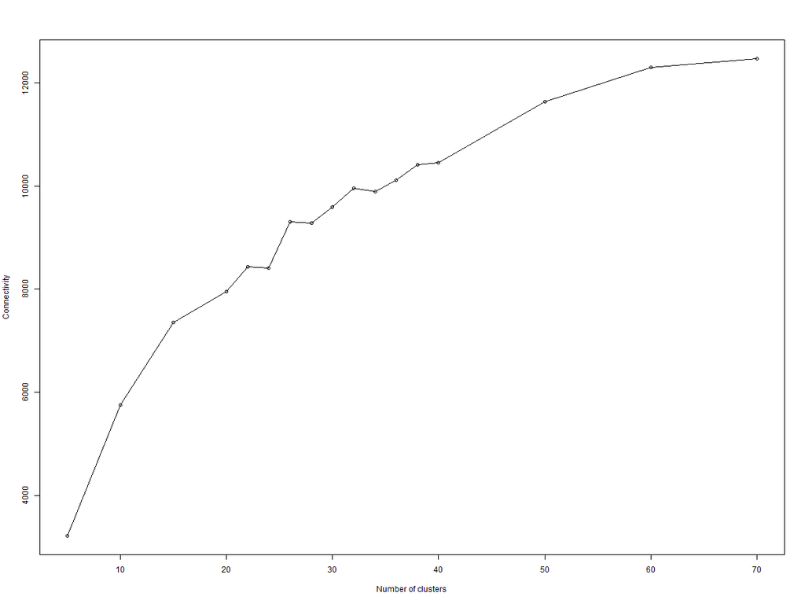

#### Internal measures: Dunn index (max)

File: meas_11511_2.png

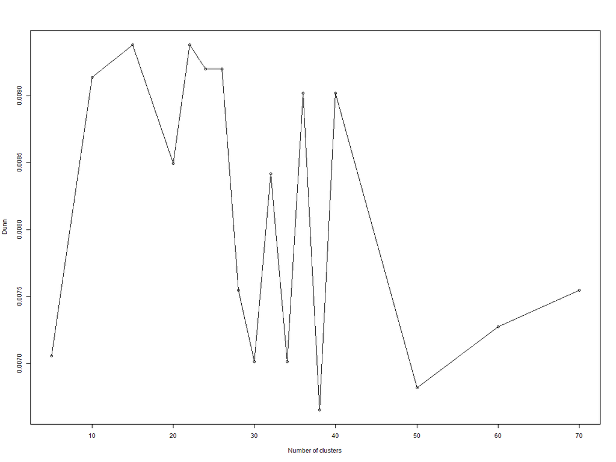

#### Internal measures: Silhouette (max)

File: meas_11511_3.png

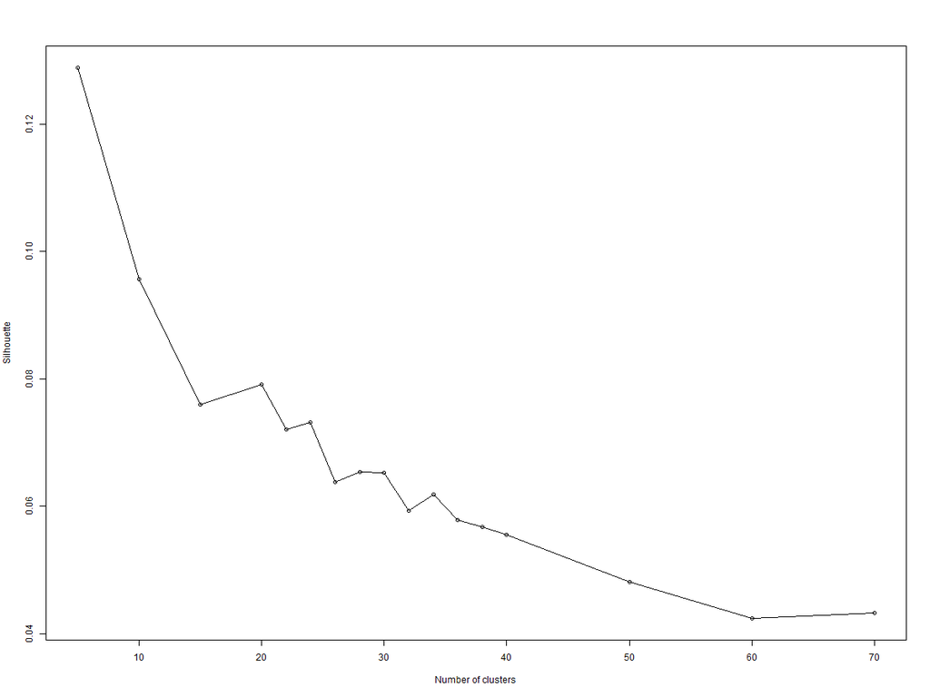

#### Stability measures: APN (min)

File: meas_11521_1.png

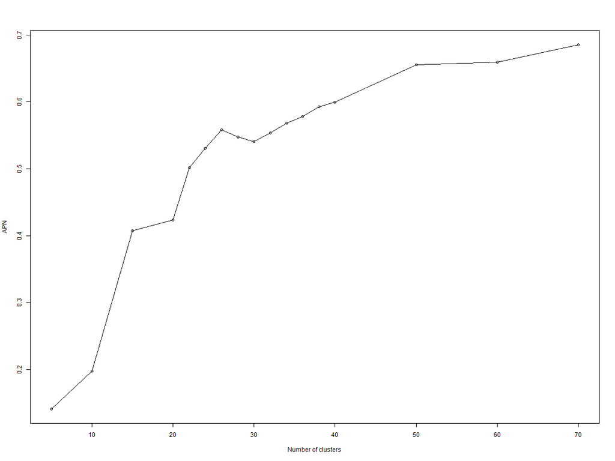

#### Stability measures: AD (min)

File: meas_11521_2.png

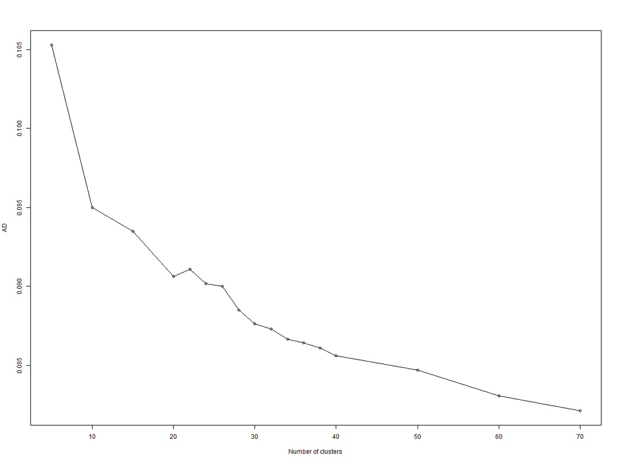

#### Stability measures: ADM (min)

File: meas_11521_3.png

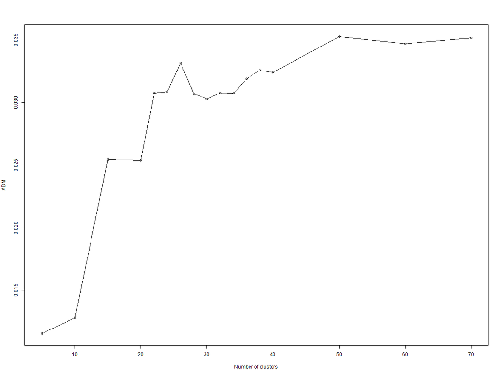

#### Stability measures: FOM (min)

File: meas_11521_4.png

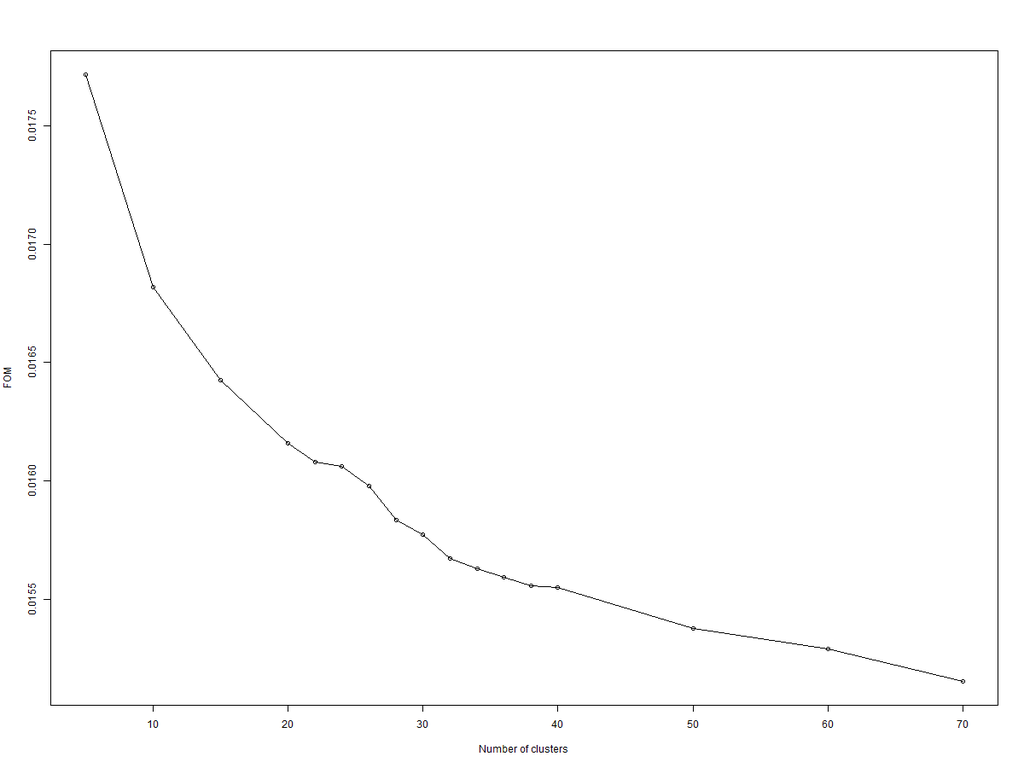

### Clustering: PAM

#### Internal measures: Connectivity (min)

File: meas_11611_1.png

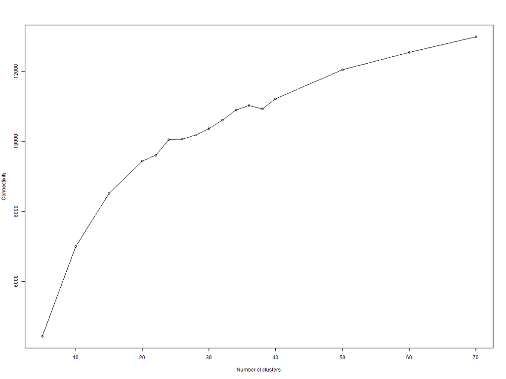

#### Internal measures: Dunn index (max)

File: meas_11611_2.png

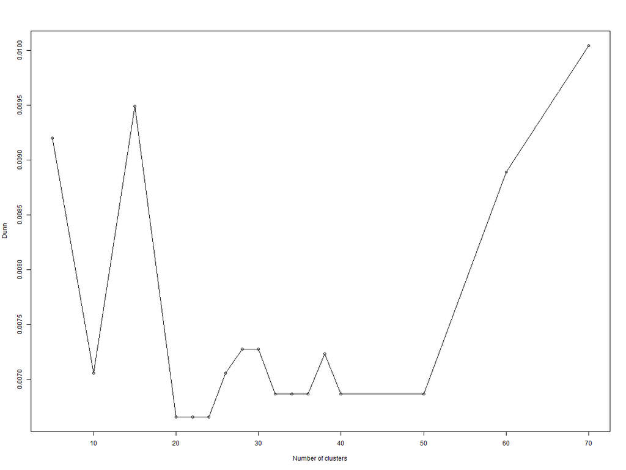

#### Internal measures: Silhouette (max)

File: meas_11611_3.png

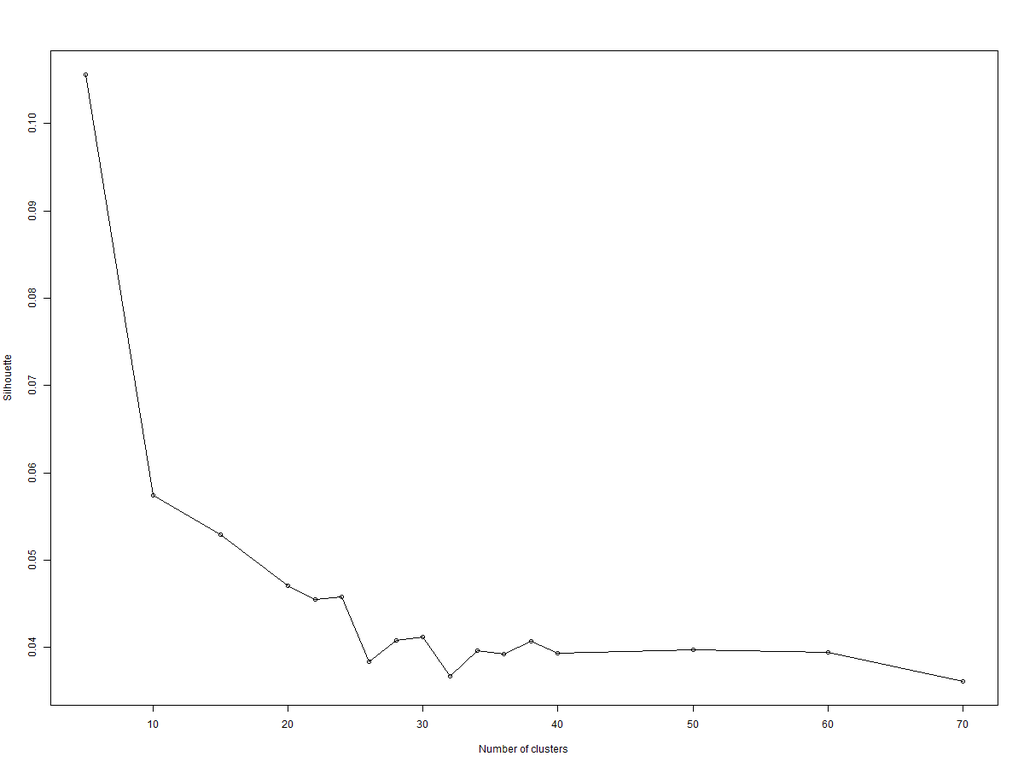

### Clustering: SOTA

#### Internal measures: Connectivity (min)

File: meas_11711_1.png

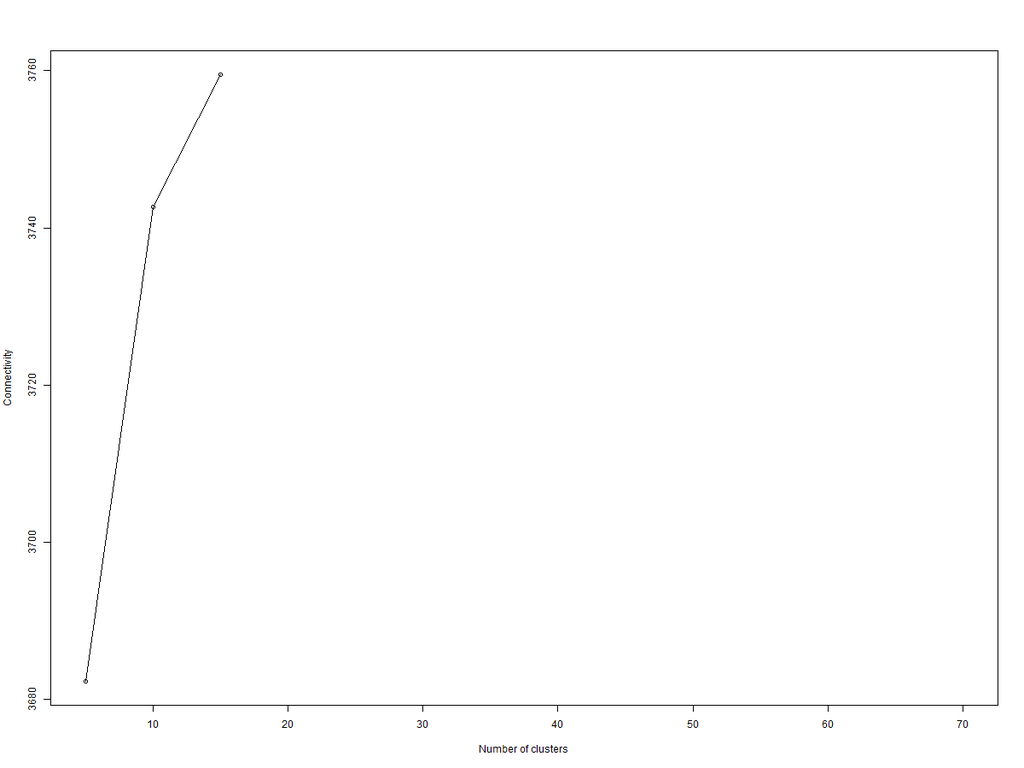

#### Internal measures: Dunn index (max)

File: meas_11711_2.png

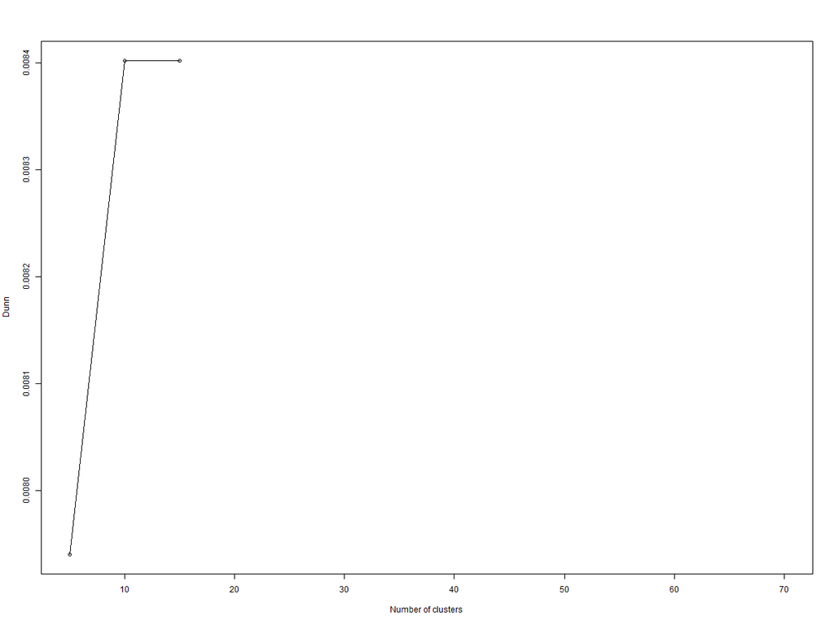

#### Internal measures: Silhouette (max)

File: meas_11711_3.png

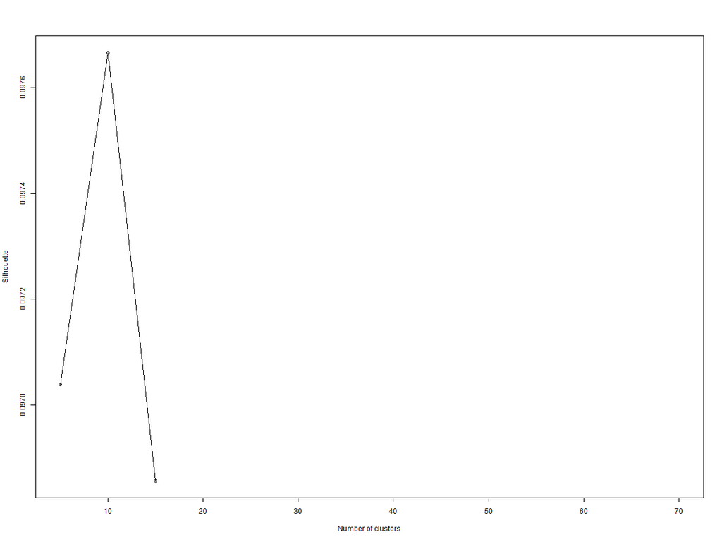

#### Stability measures: APN (min)

File: meas_11721_1.png

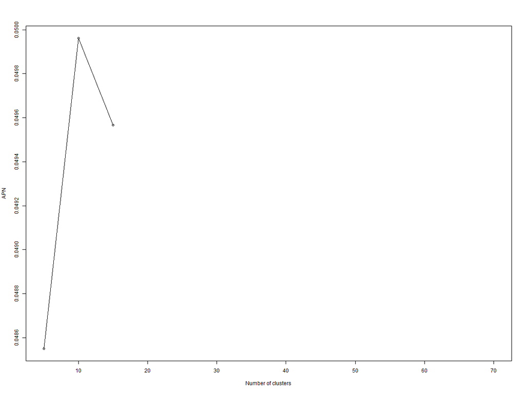

#### Stability measures: AD (min)

File: meas_11721_2.png

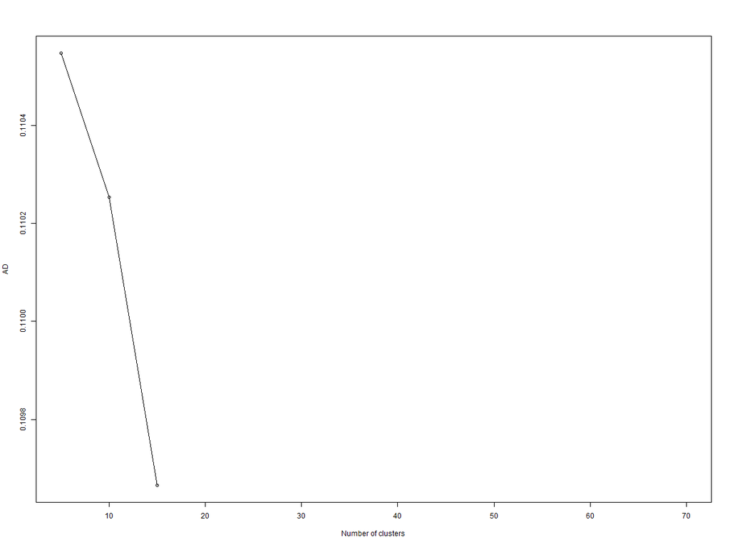

#### Stability measures: ADM (min)

File: meas_11721_3.png

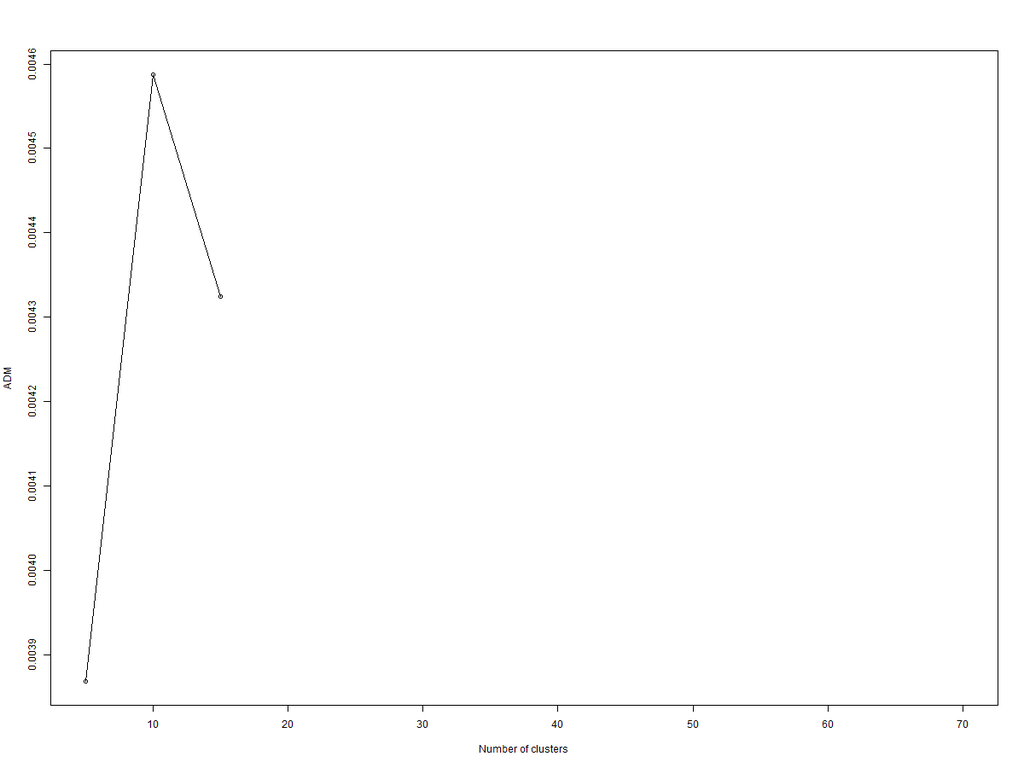

#### Stability measures: FOM (min)

File: meas_11721_4.png

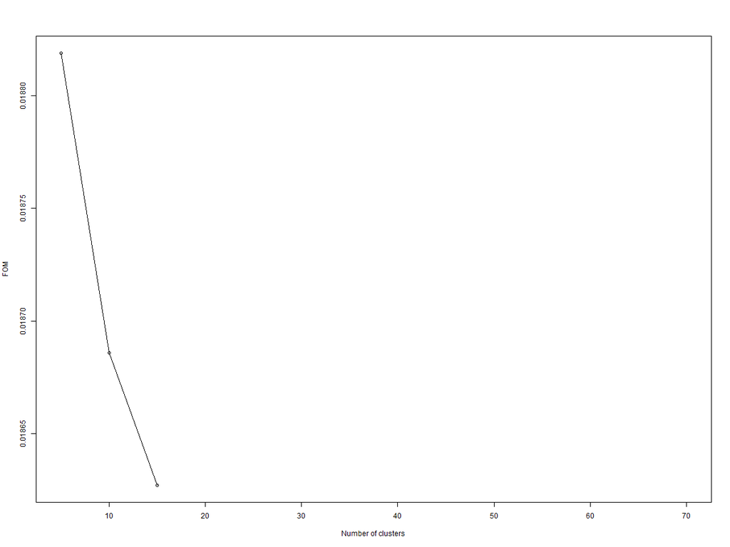

### Clustering: CLARA

#### Internal measures: Connectivity (min)

File: meas_11811_1.png

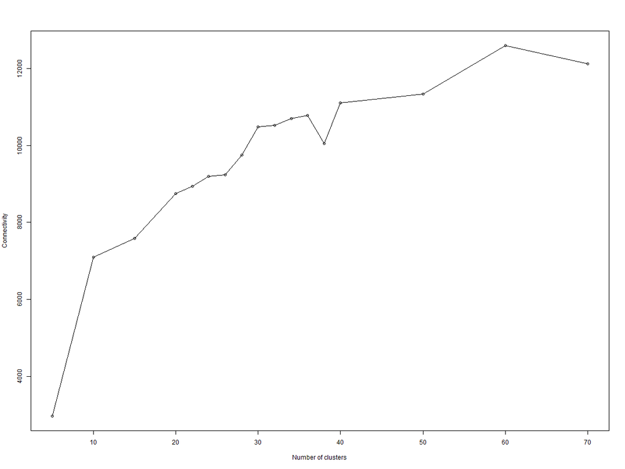

#### Internal measures: Dunn index (max)

File: meas_11811_2.png

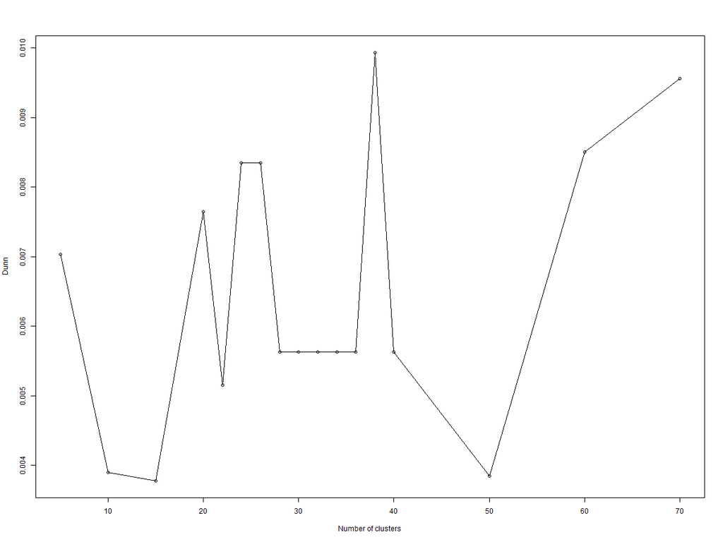

#### Internal measures: Silhouette (max)

File: meas_11811_3.png

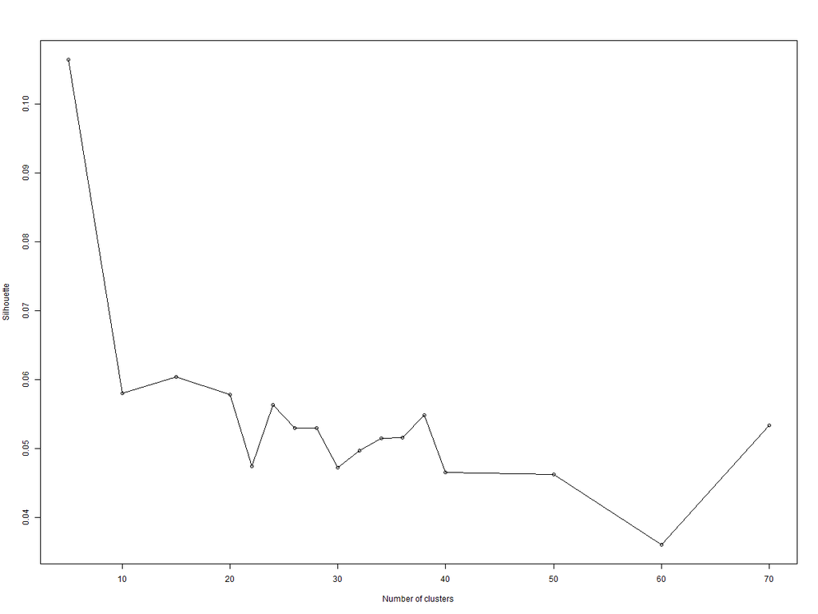

#### Stability measures: APN (min)

File: meas_11821_1.png

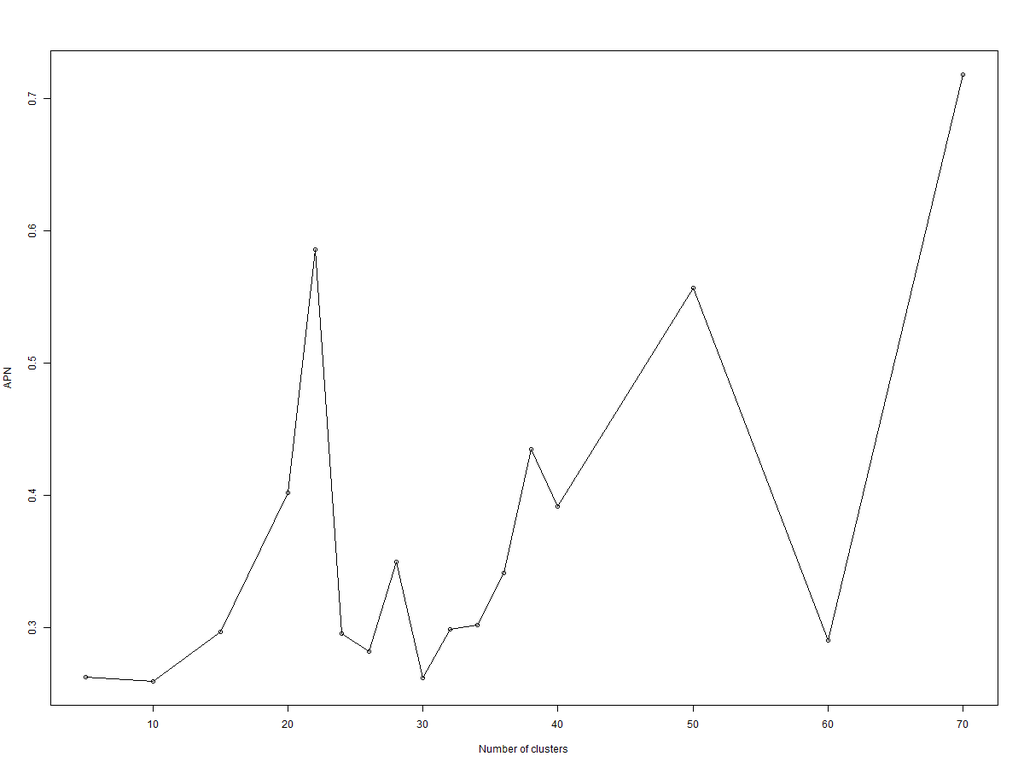

#### Stability measures: AD (min)

File: meas_11821_2.png

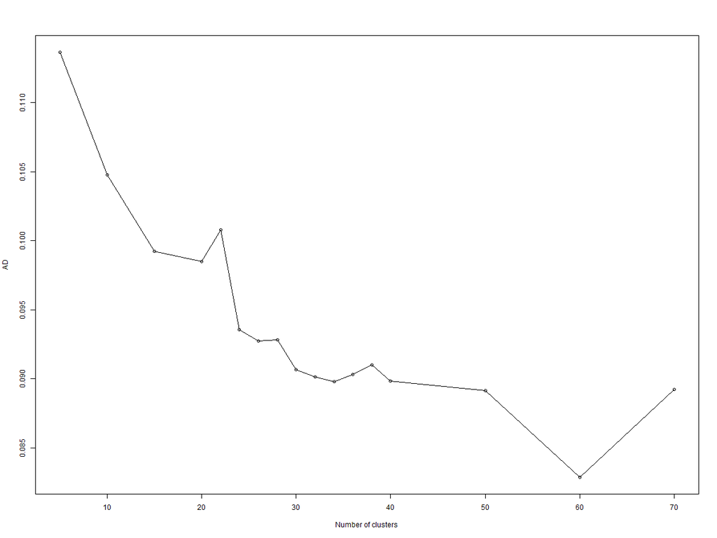

#### Stability measures: ADM (min)

File: meas_11821_3.png

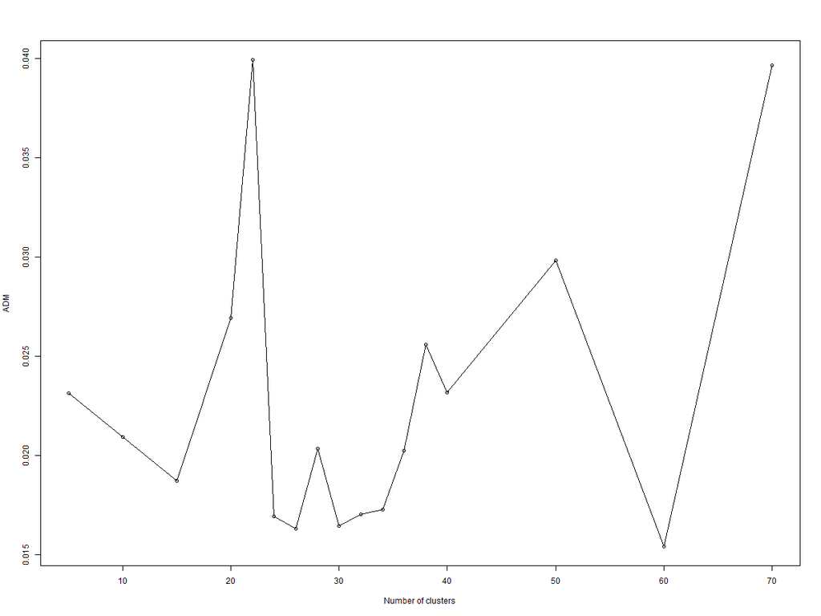

#### Stability measures: FOM (min)

File: meas_11821_4.png

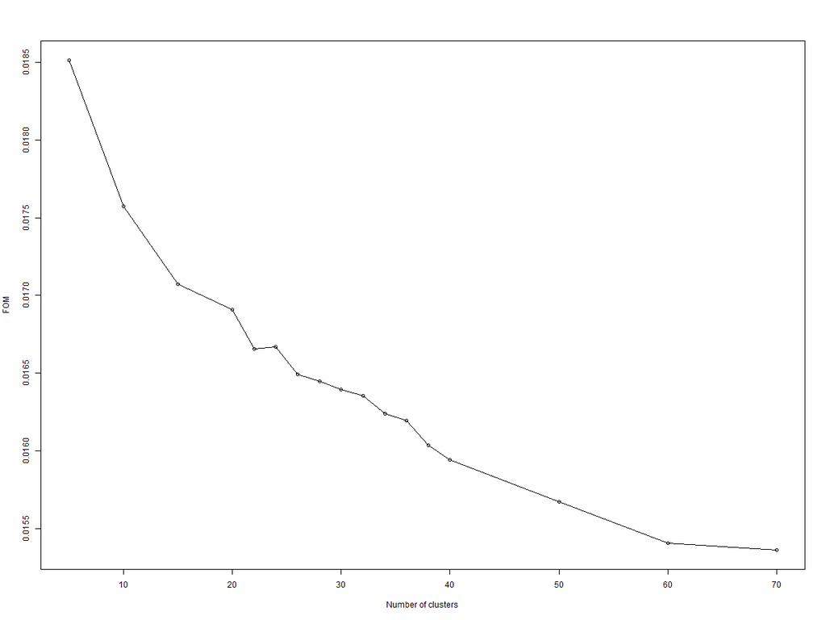

### Clustering: Model-based

#### Internal measures: Connectivity (min)

File: meas_11911_1.png

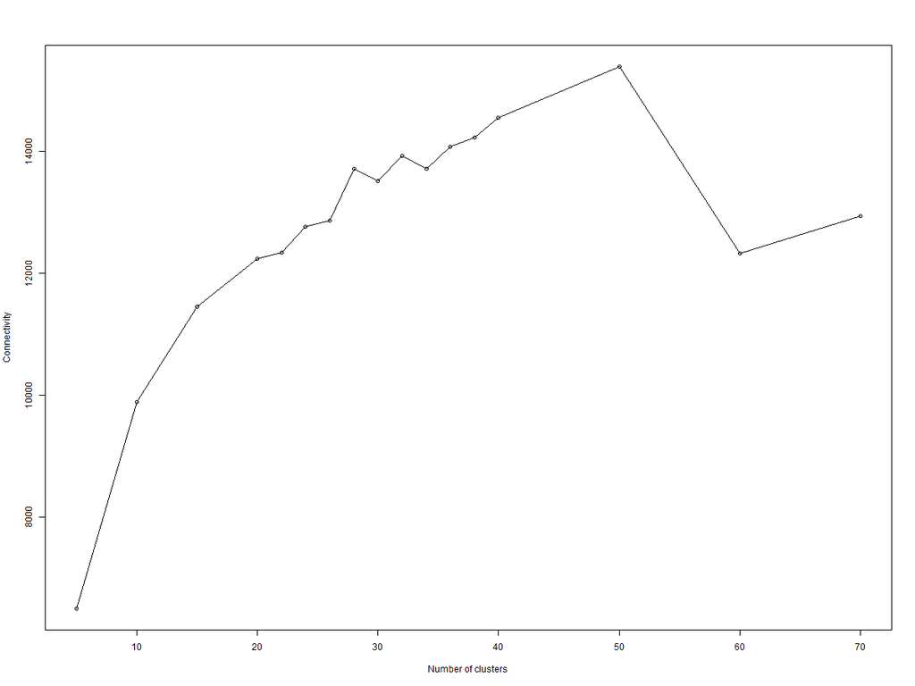

#### Internal measures: Dunn index (max)

File: meas_11911_2.png

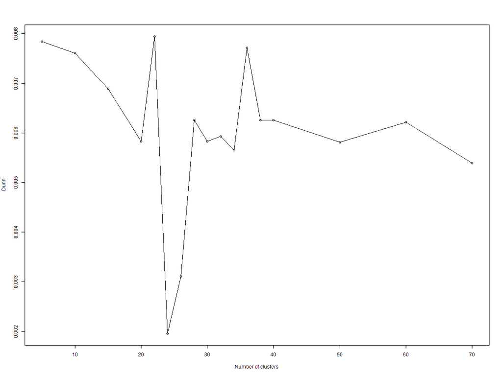

#### Internal measures: Silhouette (max)

File: meas_11911_3.png

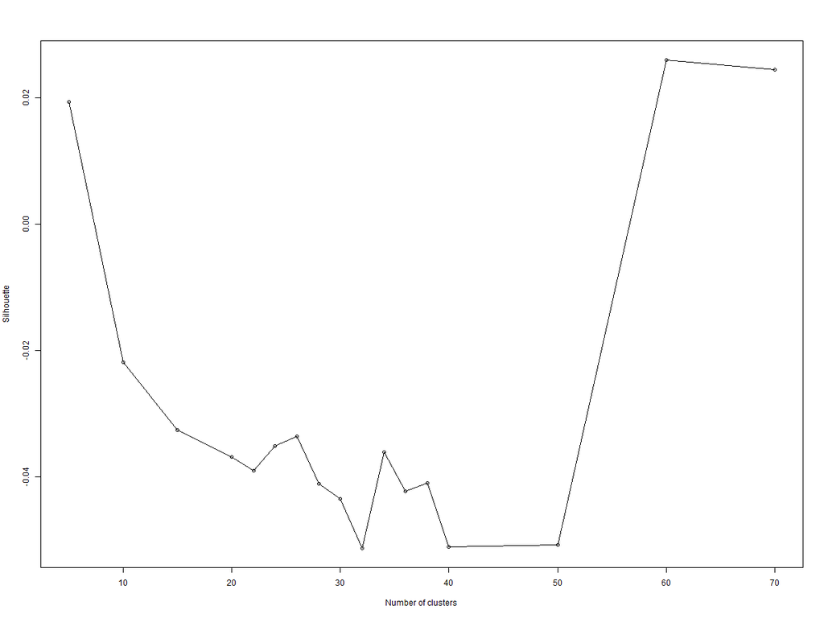

# Dataset: Low Carbon London dataset

## Set of features: seasonal aggregates

### Clustering: Hierarchical

#### Internal measures: Connectivity (min)

File: meas_12111_1.png

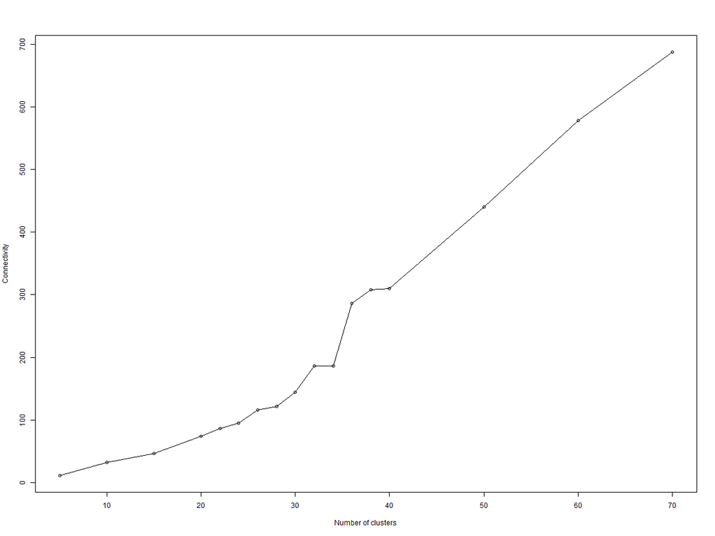

#### Internal measures: Dunn index (max)

File: meas_12111_2.png

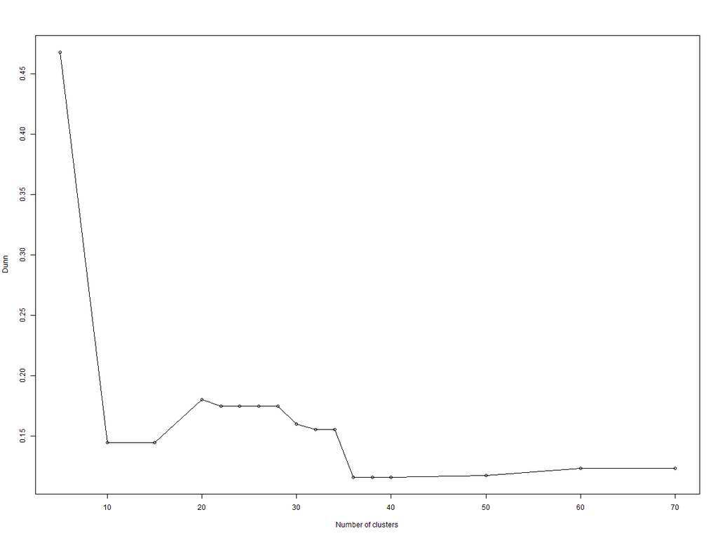

#### Internal measures: Silhouette (max)

File: meas_12111_3.png

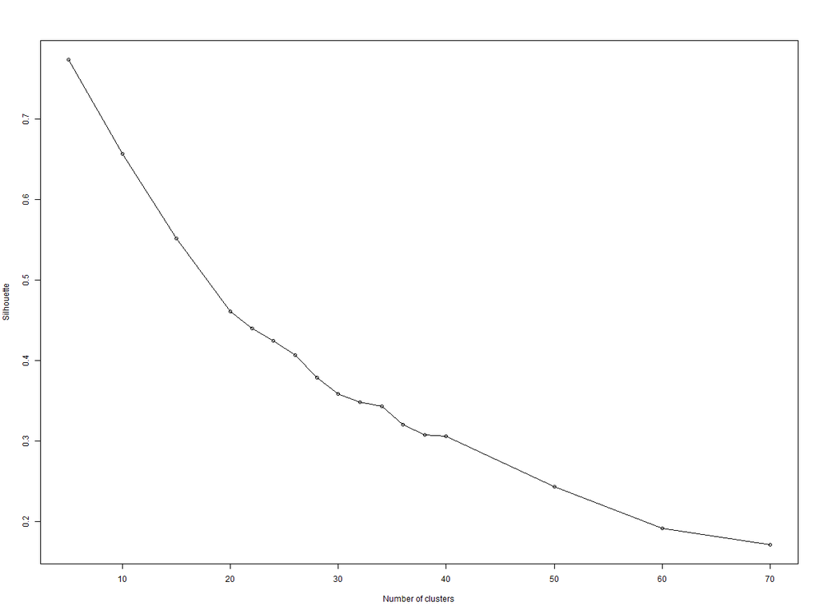

#### Stability measures: APN (min)

File: meas_12121_1.png

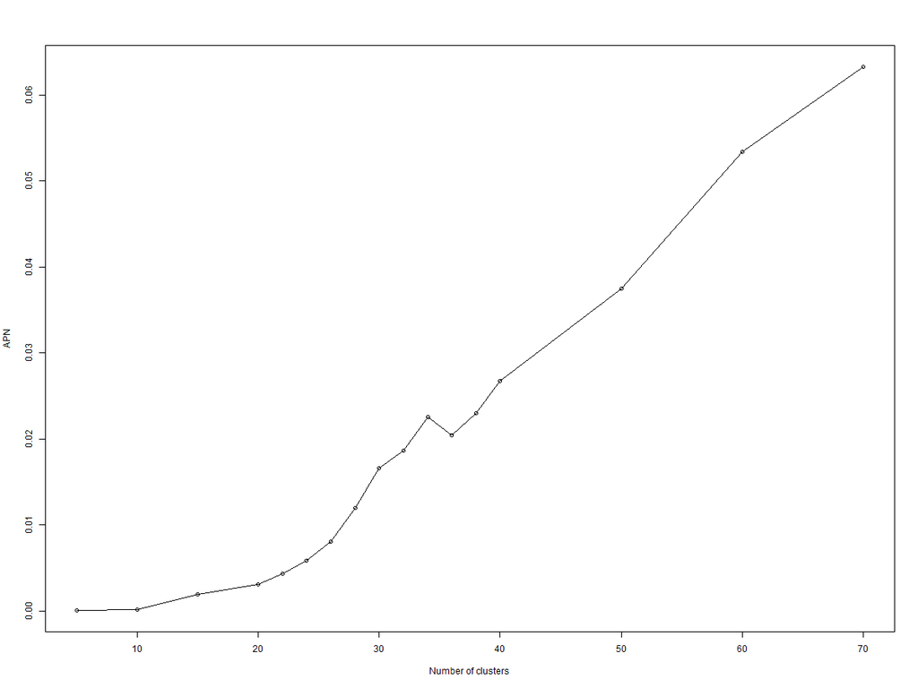

#### Stability measures: AD (min)

File: meas_12121_2.png

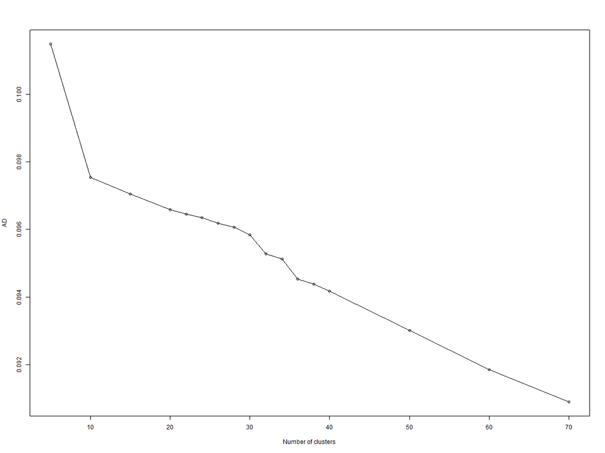

#### Stability measures: ADM (min)

File: meas_12121_3.png

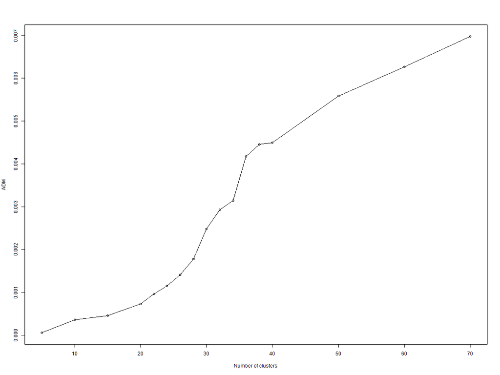

#### Stability measures: FOM (min)

File: meas_12121_4.png

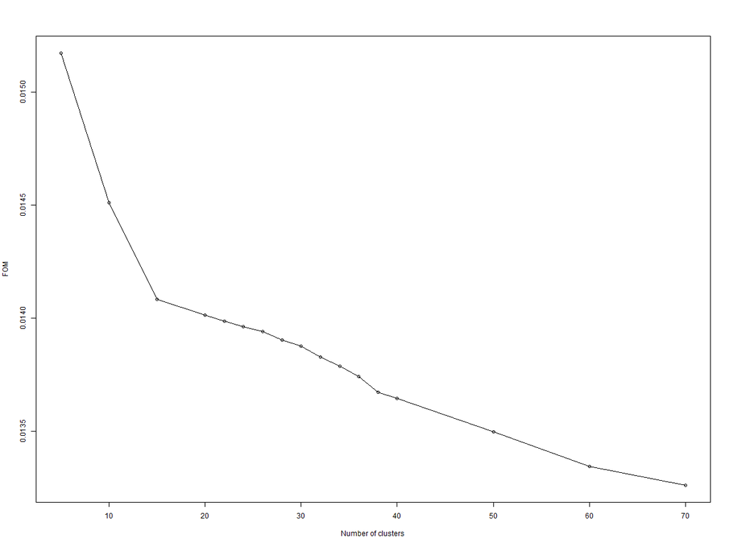

### Clustering: k-means

#### Internal measures: Connectivity (min)

File: meas_12211_1.png

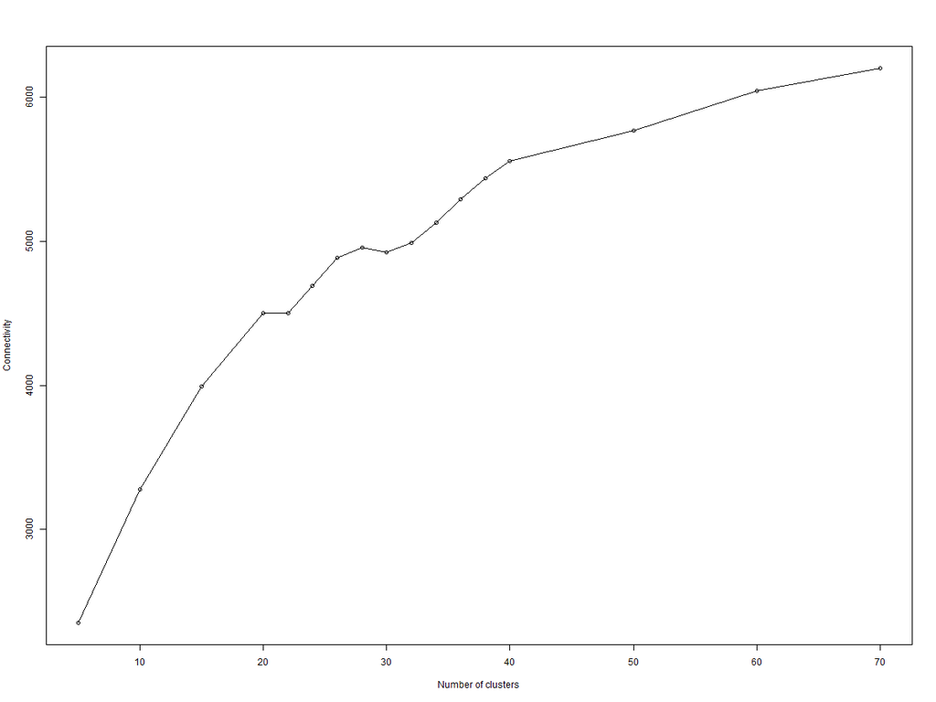

#### Internal measures: Dunn index (max)

File: meas_12211_2.png

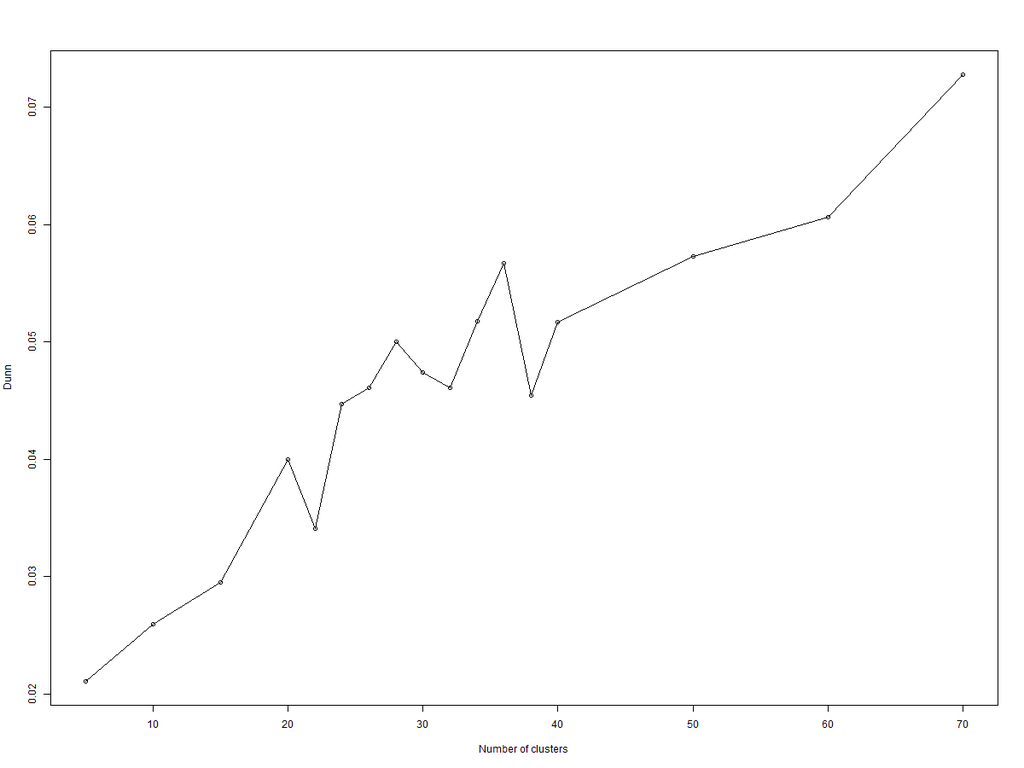

#### Internal measures: Silhouette (max)

File: meas_12211_3.png

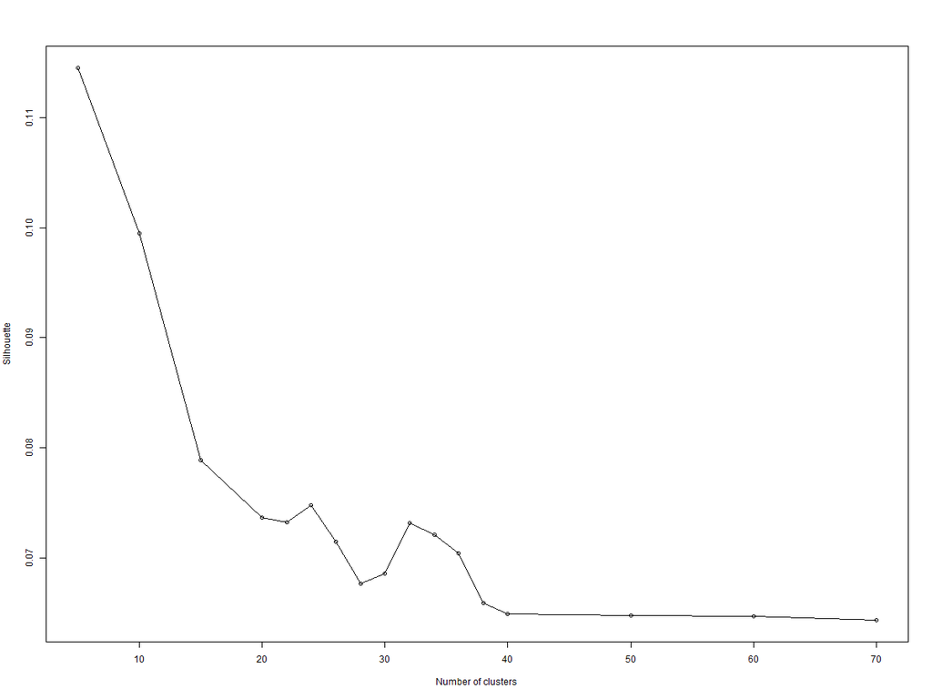

#### Stability measures: APN (min)

File: meas_12221_1.png

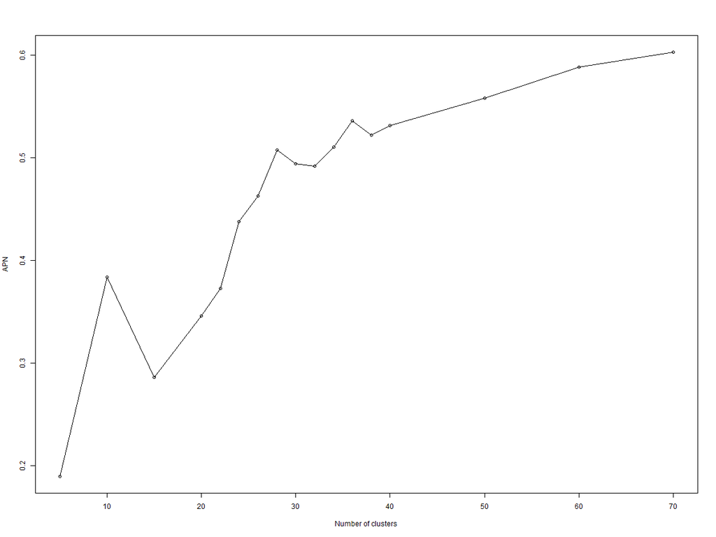

#### Stability measures: AD (min)

File: meas_12221_2.png

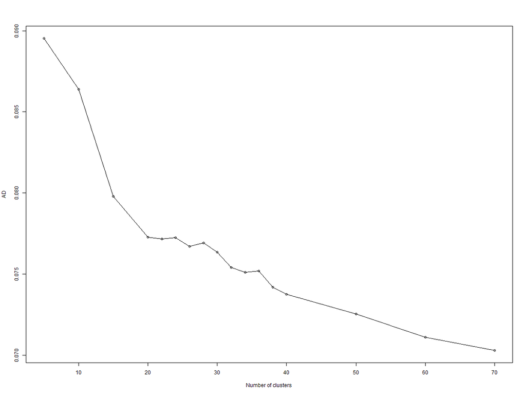

#### Stability measures: ADM (min)

File: meas_12221_3.png

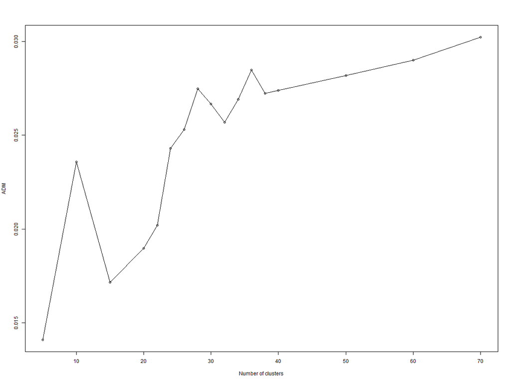

#### Stability measures: FOM (min)

File: meas_12221_4.png

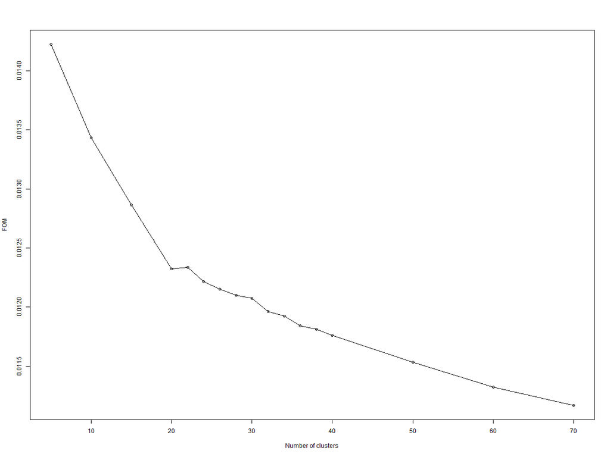

### Clustering: DIANA

#### Internal measures: Connectivity (min)

File: meas_12311_1.png

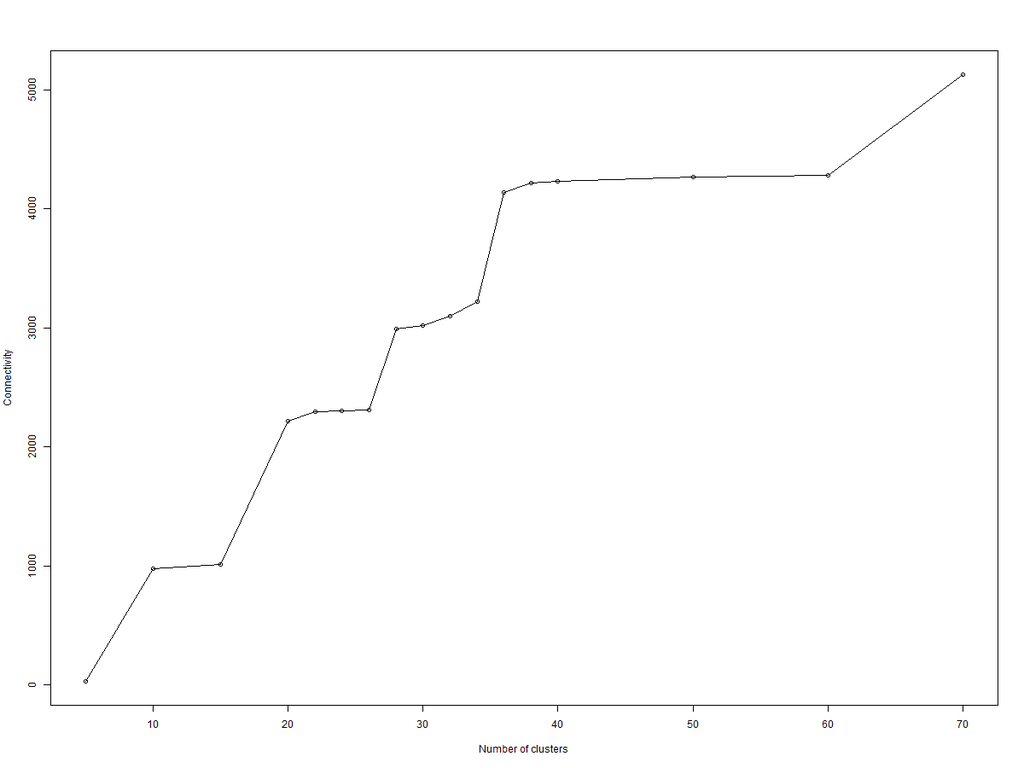

#### Internal measures: Dunn index (max)

File: meas_12311_2.png

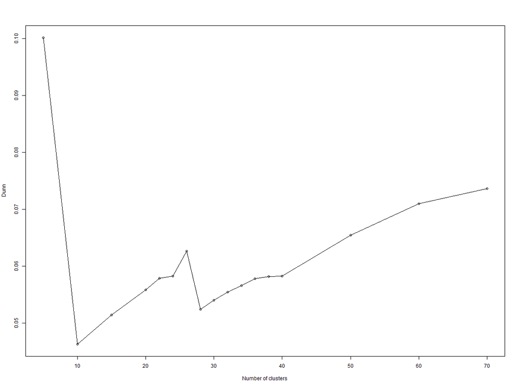

#### Internal measures: Silhouette (max)

File: meas_12311_3.png

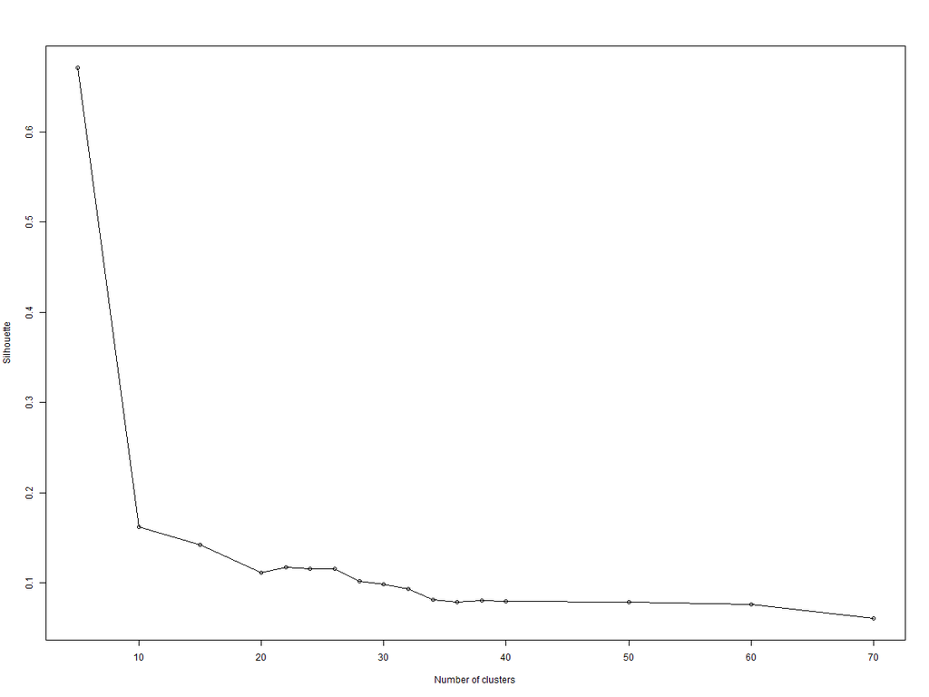

### Clustering: SOM

#### Internal measures: Connectivity (min)

File: meas_12511_1.png

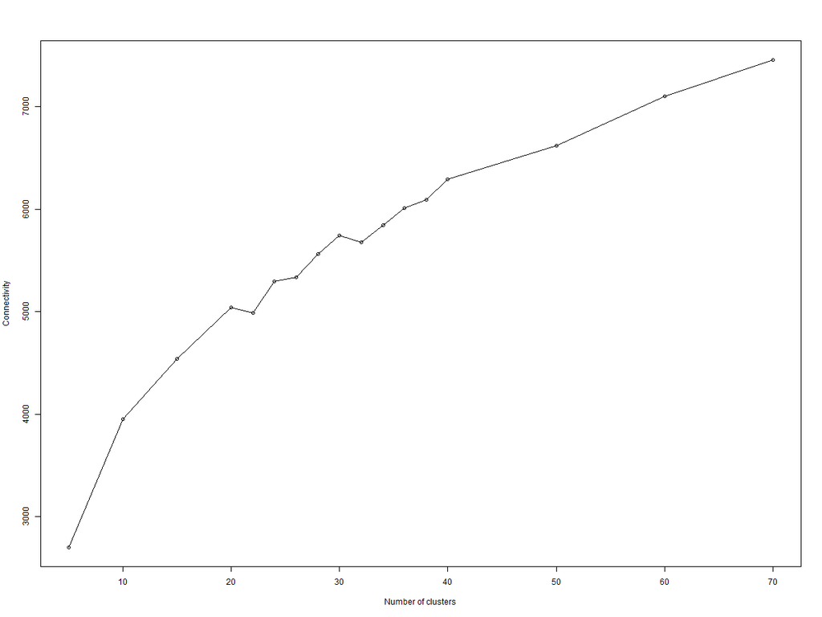

#### Internal measures: Dunn index (max)

File: meas_12511_2.png

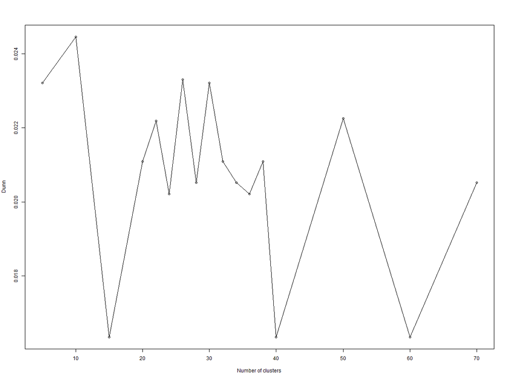

#### Internal measures: Silhouette (max)

File: meas_12511_3.png

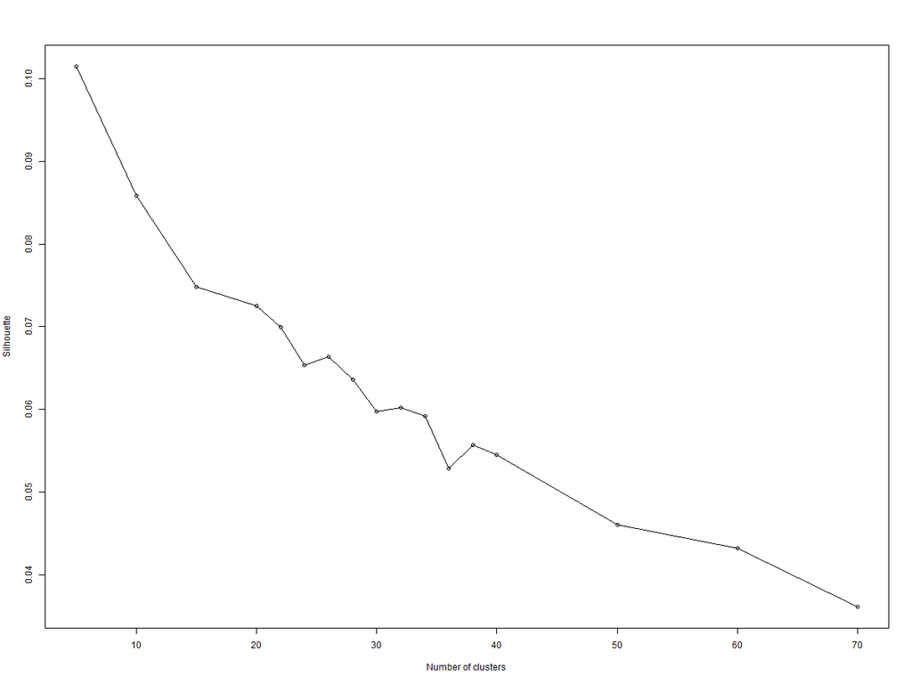